# Lecture Notes for Ch 2 of MD: Data Visualization

Dr. Hasthika Rupasinghe

Feb 01, 2021 at 06:41:43 PM

# 1 Data Visualization

We begin the development of your data science toolbox with data visualization.

First we need to get a sense of the variable types (data types). Mainly, there are ____ types of variables.

Examples of ___________ variables:

Examples of ____________ variables:

plots/graphics help us to identify ___________ and ____________ in our quantitative data.

A common extension of these ideas is to compare the distribution of one quantitative variable as we go across the levels of a different **categorical** variable.

# 2 Let’s start by installing and loading the following pacakges

```r
library(nycflights13)
library(ggplot2)
library(dplyr)
```

We can break a graphic into the following essential(first three) components:

- `data`: the data-set comprised of variables that we map.
- `geom`: the geometric object in question. This refers to our type of objects we can observe in our plot. For example, points, lines, bars, etc.
- `aes`: aesthetic attributes of the geometric object that we can perceive on a graphic. For example, x/y position, color, shape, and size. Each assigned aesthetic attribute can be mapped to a variable in our data-set.
- `facet` ing breaks up a plot into small multiples corresponding to the levels of another variable (Section 3.6)
- `position` adjustments for barplots (Section 3.8)

Let’s break down the grammar with an example.

We will be considering five different types of graphs.

- For **quantitative** variables
- For **qualitative** variables

*Example:* We will graphically investigate the relationship between the following two numerical variables in the `flights` data frame:

1. `dep_delay`: departure delay on the horizontal “x” axis and
2. `arr_delay`: arrival delay on the vertical “y” axis

```r
#View(flights)
data(flights)
glimpse(flights)
```

```
## Rows: 336,776
## Columns: 19
## $ year           <int> 2013, 2013, 2013, 2013, 2013, 2013, 2013, 2013, 2013, …
## $ month          <int> 1, 1, 1, 1, 1, 1, 1, 1, 1, 1, 1, 1, 1, 1, 1, 1, 1, 1, …
## $ day            <int> 1, 1, 1, 1, 1, 1, 1, 1, 1, 1, 1, 1, 1, 1, 1, 1, 1, 1, …
## $ dep_time       <int> 517, 533, 542, 544, 554, 554, 555, 557, 557, 558, 558,…
## $ sched_dep_time <int> 515, 529, 540, 545, 600, 558, 600, 600, 600, 600, 600,…
## $ dep_delay      <dbl> 2, 4, 2, -1, -6, -4, -5, -3, -3, -2, -2, -2, -2, -2, -…
## $ arr_time       <int> 830, 850, 923, 1004, 812, 740, 913, 709, 838, 753, 849…
## $ sched_arr_time <int> 819, 830, 850, 1022, 837, 728, 854, 723, 846, 745, 851…
## $ arr_delay      <dbl> 11, 20, 33, -18, -25, 12, 19, -14, -8, 8, -2, -3, 7, -…
## $ carrier        <chr> "UA", "UA", "AA", "B6", "DL", "UA", "B6", "EV", "B6", …
## $ flight         <int> 1545, 1714, 1141, 725, 461, 1696, 507, 5708, 79, 301, …
## $ tailnum        <chr> "N14228", "N24211", "N619AA", "N804JB", "N668DN", "N39…
## $ origin         <chr> "EWR", "LGA", "JFK", "JFK", "LGA", "EWR", "EWR", "LGA"…
## $ dest           <chr> "IAH", "IAH", "MIA", "BQN", "ATL", "ORD", "FLL", "IAD"…
## $ air_time       <dbl> 227, 227, 160, 183, 116, 150, 158, 53, 140, 138, 149, …
## $ distance       <dbl> 1400, 1416, 1089, 1576, 762, 719, 1065, 229, 944, 733,…
## $ hour           <dbl> 5, 5, 5, 5, 6, 5, 6, 6, 6, 6, 6, 6, 6, 6, 6, 5, 6, 6, …
## $ minute         <dbl> 15, 29, 40, 45, 0, 58, 0, 0, 0, 0, 0, 0, 0, 0, 0, 59, …
## $ time_hour      <dttm> 2013-01-01 05:00:00, 2013-01-01 05:00:00, 2013-01-01 …
```

Don’t worry for now if you don’t fully understand what this code is doing, I’ll explain this in details later, just run it all and understand that we are taking all flights and only considering those corresponding to Alaska Airlines.

```r
all_alaska_flights <- flights %>%
  filter(carrier == "AS")
```

```r
#View(all_alaska_flights)
```

## 2.1 Scatter Plots:

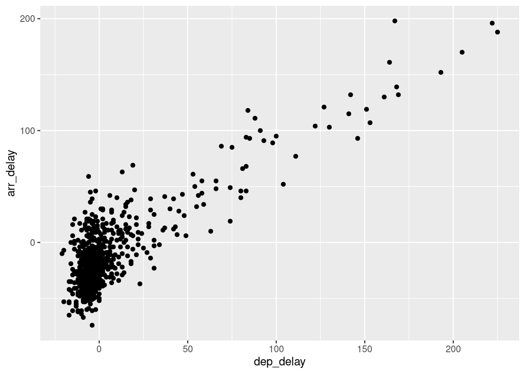

```r
ggplot(data = all_alaska_flights, mapping = aes(x = dep_delay, y = arr_delay)) +
  geom_point(alpha = 1)
```

The large mass of points near (0, 0) in this scatterplot can cause some confusion. We handle this using

1. By adjusting the ______________ of the points via the `________` argument:

```r
# your code goes here
```

2. By jittering the points via `geom_jitter()`:

Here we are to adding just a bit of random noise to the points to better see them.

```r
# your code goes here
```

## 2.2 Linegraphs

Explore the `weather` dataset from `nycflights13` package.

Type `library(nycflights13)` in the Console and hit return, then type `View(weather)` and hit return to view the data frame.

Question: Plot a time series of a variable other than temp for Newark Airport in the first 15 days of January 2013.

## 2.3 Histograms via geom_histogram

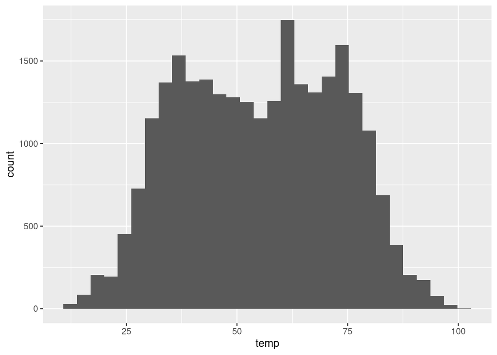

```r
ggplot(data = weather, mapping = aes(x = temp)) +
  geom_histogram()
```

We can adjust characteristics of the bins in one of two ways:

1. By adjusting the number of ______ via the `_______` argument
2. By adjusting the _________ via the `________` argument

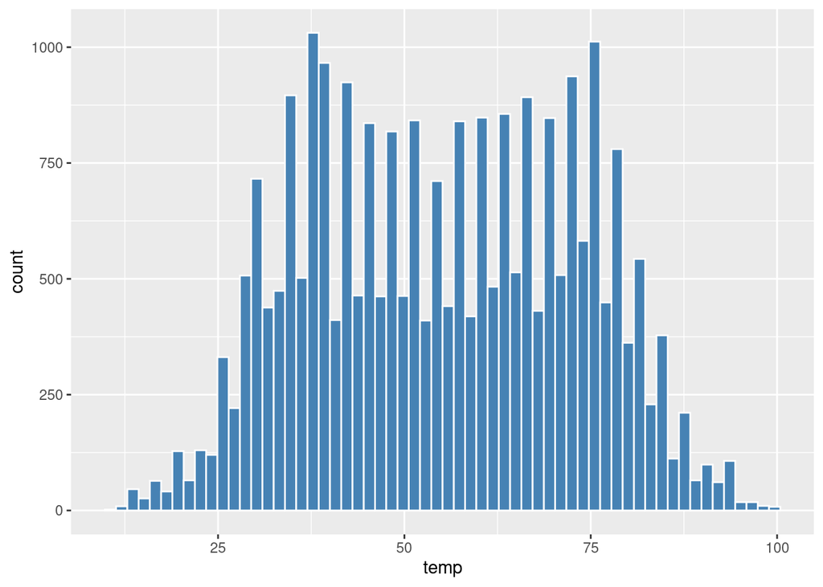

```r
ggplot(data = weather, mapping = aes(x = temp)) +
  geom_histogram(bins = 60, color = "white", fill = "steelblue")
```

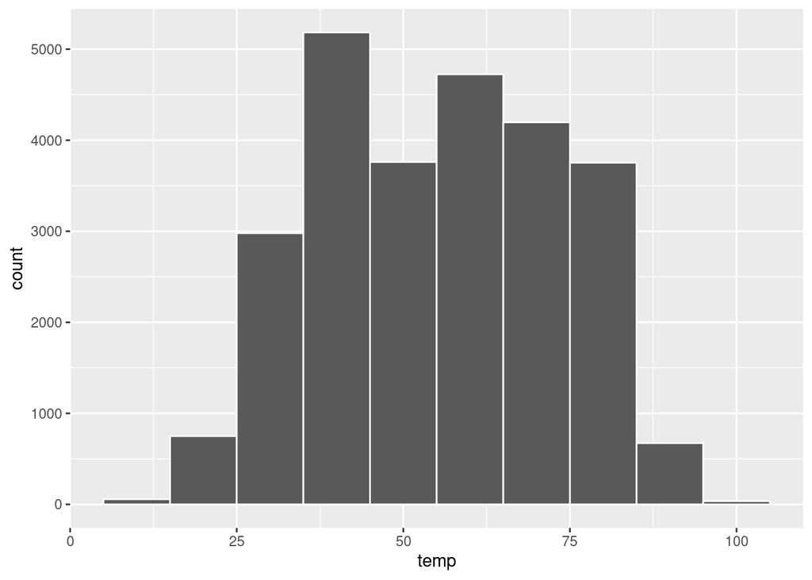

```r
ggplot(data = weather, mapping = aes(x = temp)) +
  geom_histogram(binwidth = 10, color = "white")
```

### 2.3.1 Facets

Suppose we were interested in looking at how the temperature histograms we saw above varied by month.

This is what is meant by “the distribution of a variable over another variable”: `temp` is one variable and `month` is the other variable. In order to look at histograms of `temp` for each `month`, we add a layer `facet_wrap(~ month)`.

```r
# your code goes here
```

## 2.4 Boxplots via geom_boxplot

Create a `boxplot` of of the temperature variable in the `weather` dataframe. Describe the graph briefly.

```r
# your code goes here
```

[figure not shown]

## 2.5 Barplots

Both histograms and boxplots represent ways to visualize the variability of numerical variables. Another common task is to present the distribution of a **categorical** variable. Here we explore the number of flights from each `carrier`.

```r
# your code goes here
```